# R for data science

28 March 2019

## Giraffes: Reality or myth

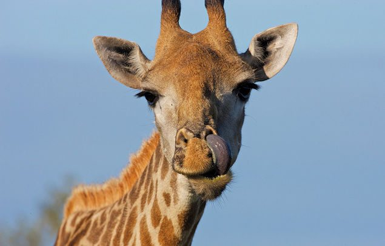

Aren’t giraffes just tall dogs?

## Naming conventions

**files** `file-example.R`  
**object/function names** `object_example`, `my_function()`  
**assign values** `my_value <- 7`  
**space** `3+ 1` (don’t do this) better to always do `3 + 1` to increase visibility.

Never but ever use `my_value = 7` it’s confusing to read and it can cause problems.

## Do’s and Dont’s

- Don’t store too much dataa into the environment. All data loaded into R is loaded into your RAM (random-access memory).
- Keep a clean script that you can run whenever you need it.

## 4. Importing and writting data

- Load flat files using base R functions
- readr & data.table (fread, fwrite)
- Import and manipulate Excel-files
- RDS and RDA

## Load flat files using base R functions

First we’ll use `read.csv()` to load two datasets.

- Chopstick Effectiveness
- Marijuana Street Price

```r
chp_eff <- read.csv("data/chopstick-effectiveness.csv", header = TRUE)
marijuana_price <- read.csv("data/marijuana_price.csv", header = TRUE)
```

`read.csv()` is appropriate for small datasets, but for larger csv files it can be a pain in the `R`.

## fread

Lets try loading the `OD_2018Q1.csv` file which contains a 10% sample of US domestic flight tickets.

`Don't run the code below`

```r
system.time(read.csv("data/OD_2018Q1.csv"))
```

Now lets try the same with the data.table package

```r
library(data.table)
system.time(fread("data/OD_2018Q1.csv", stringsAsFactors = FALSE))
```

It can be up to 20 times faster.

## fread - part II

Let’s import a big file. (factors are awful mainly when you’re importing the file)

```r
flights_18Q1 <- fread("data/OD_2018Q1.csv", stringsAsFactors = FALSE)
```

Now let’s write it again under a new name.

```r
fwrite(flights_18Q1, "flights.csv")
```

## RDS

R provides two types of datastorage, RDA and RDS.

Lets first try RDS.

```r
chp_eff <- read.csv("data/chopstick-effectiveness.csv",
                    header = TRUE)

saveRDS(chp_eff, file = "my_rds_file.rds")
my_new_dataset <- readRDS("my_rds_file.rds")
```

## RDA

Now lets try RDA.

```r
rda_df <- chp_eff # Copies chp_eff dataset to rda_df for reproducibility
save(rda_df, file = "my_rds_file.rda")
rm(rda_df) # You'll later see why we remove this part
my_pretty_rda <- load("my_rds_file.rda")
```

You see that the rda_df file we wanted was loaded with that name and not as my_pretty_rda. RDS files are often preferable, despite being slightly slower to load than RDA files.

## 5. Tidyverse for proper data science

- dplyr and piping
- lubridate (dates), stringr (strings)
- tidyr
- ggplot2

## Piping

Pipes `%>%` come from the package `magrittr` but are included in pretty much of all of the tidyverse. Their usage is simple. When using a `%>%` after a dataframe, the dataframe reference is transported to the rest of the code.

```r
library(dplyr)
chp_eff %>%
  summarise(mean = mean(Chopstick.Length))
```

This can be useful in many contexts as it makes code readable.

## Dplyr

Dplyr is part of the tidyverse package and it was created initially by Hadley Wickham. The main foundations of this package are readeability and dataframe structure (called tidydata). The process of working with tidydata is Import - Tidy - (Transform - Visualize - Model) - Communicate.

## Tibles

```r
library(tibble)
as_tibble(chp_eff)
as.data.frame(chp_eff)
```

Running `as_tibble` and `as.data.frame` shows that tibble can carry more information on the dataframe being used. This can be useful when working with large datasets.

## Group_by, Summarize, Mutate, Filter, Select

The `tidyverse` has 5 important functions to manipulate datasets. `group_by()`, `summarise()`, `mutate()` `filter()` and `select()`

```r
library(dplyr)
marijuana_price <- read.csv("data/marijuana_price.csv",
                            header = TRUE)

marijuana_price %>%
  group_by(State) %>% # groups by individual
  summarise(highq_mean = mean(HighQ),
            highq_sum = sum(HighQN))
```

## Group_by, Summarize, Mutate

```r
library(dplyr)
library(lubridate) # To get month

marijuana_price %>%
  mutate(month = month(date)) %>%
  group_by(State, month) %>%
  summarise(highq_mean = mean(HighQ),
            highq_sum = sum(HighQN))
```

## Group_by, Summarize, Mutate, Filter

```r
library(dplyr)
library(lubridate) # To get month

marijuana_price %>%
  mutate(month = month(date)) %>%
  filter(month == 1, HighQN >= 600) %>%
  group_by(State) %>%
  summarise(highq_mean = mean(HighQ),
            highq_sum = sum(HighQN))
```

Note the `==`. In R conditions are matched with `==`, `!=`, `>`, `>=`, `<` and `<=`.

## Select

```r
library(dplyr)

marijuana_price %>%
  select(State, HighQ)

marijuana_price %>%
  select(-LowQ, -LowQN)
```

`-` before the object, removes it from selection.

## Magical if if if if (case_when)

```r
library(dplyr)

marijuana_price <- read.csv("data/marijuana_price.csv",
                            header = TRUE)

marijuana_quarter <- marijuana_price %>%
  mutate(month = month(date))

marijuana_quarter %>%
  mutate(quarter = case_when(month >= 1 & month <= 3 ~ "Q1",
                             month >= 4 & month <= 6 ~ "Q2",
                             month >= 7 & month <= 9 ~ "Q3",
                             month >= 10 & month <= 12 ~ "Q4"))
```

## Joining “stuff”

```r
library(dplyr)
library(lubridate) # To get month

stacking <- read.csv("data/world-sport-stacking.csv",
                            header = TRUE)

stacking_comp <- read.csv("data/stacking_comp.csv")

stacking_full <- left_join(stacking, stacking_comp,
                           by = "Competitor")
```

There are several types of join which can be found in detail here https://dplyr.tidyverse.org/reference/join.html

## Lubridate

```r
library(lubridate)

lubridate::month("2011-04-24")
lubridate::day("2011-04-24")
lubridate::wday("2011-04-25", label = TRUE)

time <- ymd_hms("2010-12-13 15:30:30")
with_tz(time, "America/Chicago")
```

More information on lubridate here https://lubridate.tidyverse.org.

## Stringr

```r
library(stringr)

word <- "Rindfleischetikettierungsüberwachungsaufgabenübertragungsgesetz"
calvin1 <- "It's not denial."
calvin2 <- "I'm just selective about the reality I accept."

str_length(word)
str_count(word, "e")
str_count(word, "ü")

calvin <- paste(calvin1, calvin2)

str_split(calvin, " ")
str_split(calvin, "[.]")
```

## Tidyr - Spread

`data %>%`  
`spread(grouped_var, value)`

```r
library(tidyr)
library(dplyr)

sleep <- read.csv("data/sleep.csv")
sleep_sp <- sleep %>%
  spread(group, extra)
sleep_sp
```

## Tidyr - Gather

`data %>%`  
`gather(new_var, key_val, col_a:col_b)`

```r
library(tidyr)
library(dplyr)

colnames(sleep_sp) <- c("patient", "drug_1", "drug_2")
sleep_sp %>%
  gather(drug, patient, drug_1:drug_2)
```

## ggplot2

```r
library(tidyverse)

head(mpg)
ggplot(mpg, aes(displ, hwy, colour = class)) +
  geom_point()
```

`ggplot(data, aes(x, y, colour))` # graph  
`geom_point` # type of graph

## ggplot2

```r
library(tidyverse)

ggplot(mpg, aes(displ, hwy, colour = class, size = displ)) +
  geom_point()

ggplot(mpg, aes(displ, hwy)) +
  geom_point(aes(colour = class, size = displ)) #same as previous code block

ggplot(mpg, aes(displ, hwy, colour = class)) +
  geom_point(size = .3)
```

The `aes()` section is meant for variables affecting aesthetics. For fixed sizes, colors, etc., define the variable outside of aes.

## 6. data.table

## DT[i, j, by]

Working in i.

```r
library(data.table)

DT <- fread("data/OD_2018Q1.csv")
class(DT)
DT <- as.data.table(DT) #in case we hadn't import it with fread.
colnames(DT)

JFK_ATL <- DT[origin == "JFK" & dest == "ATL"]
#note that we separate multiple conditions with &
JFK_ATL[order(-itin_yield)]
```

## DT[i, j, by]

Working in j.

```r
library(data.table)

DT[,dest] #returns column as vector
DT[,.(dest)] #returns data.table

DT[origin == "JFK",.(itin_yield = mean(itin_yield))]

DT[,.(itin_yield = mean(itin_yield)), by = c("origin", "dest")]
```

i does operations for filtering and ordering j does operations for calculating new fields, similar to `mutate()` in dplyr. by is similar to `group_by()` in dplyr.

## .N and other special operators

```r
library(data.table)

DT[,.(itin_yield = mean(itin_yield), count = .N),
   by = c("origin", "dest")]

DT[,.(itin_yield = mean(itin_yield), count = .N),
   by = c("origin", "dest")][order(origin, dest)]
```

`.N` counts number of elements in grouped data.  
We can chain data.table data, by stacking `[]`.  
`DT[...][...][...][...]`

## .N and other special operators

```r
library(data.table)

JFK <- DT[origin == "JFK"]

JFK[,`:=`(new_var, itin_fare/distance)]
head(JFK) #new var was calculated

JFK[,new_var2:=itin_fare/distance]
head(JFK) #new var was calculated
```

Why using the `:=` operator. As it doesn’t create a new table, it’s faster to calculate new variables. However, it adds the new column immediately even though we didn’t use the `<-` operator. It only does row-wise operations and it doesn’t aggregate data.

## 7. Increase Speed

```r
system.time(DT[order(mkt_id, seq_num)]) #data.table

system.time(arrange(DT, mkt_id, seq_num)) #dplyr

system.time(DT[,.(mean_fare = mean(itin_fare),
                  passengers = sum(passengers),
                  mean_yield = mean(itin_yield)),
               by = c("origin", "dest")]) #data.table

system.time(DT %>%
               group_by(origin, dest) %>%
               summarise(mean_fare = mean(itin_fare),
                         passengers = sum(passengers),
                         mean_yield = mean(itin_yield))
              ) #dplyr
```

## 7. Increase Speed

When `elapsed < user` it means that the package is using the multi-core possibilities within your computer.

## Using dplyr and data.table together

```r
df$stop_times %>%
  left_join(trip, by = "trip_id") %>%
  group_by(trip_id, date) %>%
  arrange(trip_id, date, stop_sequence) %>%
  mutate(dest = lead(stop_id)) %>%
  as.data.table() %>%
  .[!is.na(dest)] %>%  # data.table section to improve speed
  {if (!is.null(dayf)) .[date %in% dayf] else .} %>%
  as.tibble() %>%
  mutate(hours = hour(hms(arrival_time))) %>% #new
  select(origin = stop_id, dest,
         travel_time, trip_id, arrival_time,
         departure_time, stop_sequence, hours) %>%
  group_by(origin, dest, hours) %>%
  summarise(travel_time = round(mean(travel_time)),
            freq = n()) %>%
  group_by(origin, dest) %>%
  summarise(travel_time = round(mean(travel_time)),
            freq = mean(freq)) %>%
  mutate(weight = 4 * sqrt(travel_time/freq))
```

## Why you shouldn’t use SQL

**SQL**

- Database setup can be messy
- Relational databases need strict structure
- Non relational databases are prone to integrity issues

**data.table**

- Can store data in csv
- Faster or same speed as SQL query
- No need to have external database
- Portability between computers without any specific data requirements

## 8. Showing off with R

Project developed by Freke Caset and Filipe Teixeira

https://railacc.ugent.be/GTFScentrality/

## sf (simple features)

Why simple features? It is a widely supported data model that underlies data structures in many GIS applications including QGIS and PostGIS. We do have already the sp package for that, so why the sf package.

- sf package allows treating sf objects as data frames
- it can be combined with %>%
- function names are intuitive and start with st_

## sf (simple features)

```r
library(sf)
library(sp)

point <- st_point(c(5, 2))
plot(point) #point

linestring <- rbind(c(5,2),c(1,3),c(3,4), c(3,2))
linestring <- st_linestring(linestring)
plot(linestring) #linestring

polygon_border <- rbind(c(1,5), c(2,2),
                        c(4,1), c(4,4), c(1,5))
polygon_hole <- rbind(c(2,4), c(3,4),
                      c(3,3), c(2,3), c(2,4))
polygon_with_hole_list <- list(polygon_border, polygon_hole)
polygon_with_hole <- st_polygon(polygon_with_hole_list)
plot(polygon_with_hole)
```

## leaflet

```r
library(leaflet)
library(rgdal)

jfk_shp <- readOGR("data/jfk.shp")
jfk_shp <- spTransform(jfk_shp,
                       CRS("+proj=longlat +datum=WGS84"))
class(jfk_shp)

colnames(jfk_shp@data) #for popup window

leaflet() %>%
  addProviderTiles("CartoDB.Positron") %>%
  addPolygons(data = jfk_shp, color = "royalblue", weight = 1,
               opacity = .6, label = ~paste(pop2010))
```

## leaflet

`leaflet()` creates support for map `addProviderTiles()` adds basemap `addPolygons()` adds polygons

One characteristic of leaflet is that the `aes()` or individual variables are set with a `~`.

## Interactive visuals with Shiny (example)

www.railacc.ugent.be

**user:** stations_radar  
**password:** Rcourse

## Interactive visuals with Shiny

Anatomy of a Shiny server app.

- **server.R** - handles all data generation and filtering
- **ui.R** - handles all user interaction
- **global.R** - to load data

## Interactive visuals with Shiny

```r
library(shiny)

# Define UI for application that draws a histogram
ui <- fluidPage(
    theme = "bootstrap.css",

    # Application title
    titlePanel("Old Faithful Geyser Data"),

    # Sidebar with a slider input for number of bins
    sidebarLayout(
        sidebarPanel(
            sliderInput("bins",
                        "Number of bins:",
                        min = 1,
                        max = 50,
                        value = 30)
        ),

        # Show a plot of the generated distribution
        mainPanel(
           plotOutput("distPlot")
        )
    )
)

# Define server logic required to draw a histogram
server <- function(input, output) {

    output$distPlot <- renderPlot({
        # generate bins based on input$bins from ui.R
        x    <- faithful[, 2]
        bins <- seq(min(x), max(x),
                    length.out = input$bins + 1)

        # draw the histogram with the specified number of bins
        hist(x, breaks = bins,
             col = 'darkgray', border = 'white')
    })
}

# Run the application
shinyApp(ui = ui, server = server)
```

## Introduction to network analysis with igraph

```r
library(igraph)
library(data.table)
library(dplyr)

OD <- fread("data/OD_2018Q1.csv")
OD <- OD %>%
  group_by(origin, dest) %>%
  summarise(passengers = sum(passengers),
            itin_yield = mean(itin_yield),
            itin_fare = mean(itin_fare))

g <- graph_from_data_frame(OD, directed = TRUE)

summary(g)
```

## Introduction to network analysis with igraph

```r
E(g)$passengers
E(g)$itin_yield

degree(g)

V(g)$degree <- degree(g)
summary(g)
V(g)$degree

eigen_centrality(g)$vector
closeness(g)


plot(g, vertex.label = NA, vertex.size = 4,
     vertex.frame.color = "white",
     edge.width = .1, edge.arrow.mode = 0,
     layout = layout_on_sphere(g))
```

## Introduction to network analysis with igraph

```r
library(tidygraph)

g %>%
  as_tbl_graph() %>%
  activate(nodes) %>%
  mutate(degree = centrality_degree())
```

- The igraph object has to be converted to tbl_graph
- The function `activate()` tells tidygraph if you’re working with `nodes` or `edges`.

## Thank you

Please fill in this survey.

https://forms.gle/mVWuSC8SJJc8bUXd8